# Boston Housing: Regression Example

```python
import pandas as pd
import numpy as np
from matplotlib import pyplot as plt

from keras.datasets import boston_housing
from keras import models, layers
```

# 1. Data

```python
(train_data, train_targets), (test_data, test_targets) = boston_housing.load_data()
```

Let's have a look at the shape of the data.

```python
print(train_data.shape)
print(test_data.shape)
```

```
(404, 13)
(102, 13)
```

The house price is quoted in thousands of dollars.

```python
print(train_targets[:10])
```

```
[15.2 42.3 50.  21.1 17.7 18.5 11.3 15.6 15.6 14.4]
```

## 1.1. Data Manipulation

As the scales of the features are different, we choose to first normalize the features. We normalize the data using the mean and standard deviation of just the training data to avoid data leakage.

```python
mean = train_data.mean(axis=0)
train_data -= mean
std = train_data.std(axis=0)
train_data /= std

test_data -= mean
test_data /= std
```

# 2. Defining Network Architecture

We define a densely-connected network with the final layer having no activation function (i.e. it's a linear layer). This is typically what is done with regression problems.

As we are expecting to instantiate the same model multiple times, we shall use a function to onstruct it.

```python
def build_model():
    model = models.Sequential()
    model.add(layers.Dense(64, activation='relu', input_shape=(train_data.shape[1], )))
    model.add(layers.Dense(64, activation='relu'))
    model.add(layers.Dense(1))
    model.compile(optimizer='rmsprop', loss='mse', metrics=['mae'])
    return model
```

# 3. Training the model

As the training set is so small, we use 4-fold cross validation to get a more precise estimate of model performance.

```python
k = 4
num_val_samples = len(train_data) // k
num_epochs = 100
all_scores = []

for i in range(k):
    print('processing fold #', i)
    val_data = train_data[(i * num_val_samples): ((i + 1) * num_val_samples)]
    val_targets = train_targets[(i * num_val_samples): ((i + 1) * num_val_samples)]

    partial_train_data = np.concatenate([train_data[:(i * num_val_samples)],
                                        train_data[((i + 1) * num_val_samples):]], axis=0)
    partial_train_targets = np.concatenate([train_targets[:(i * num_val_samples)],
                                            train_targets[((i + 1) * num_val_samples):]], axis=0)

    model = build_model()
    model.fit(partial_train_data, partial_train_targets, epochs=num_epochs,
              batch_size=1, verbose=0)
    val_mse, val_mae = model.evaluate(val_data, val_targets, verbose=0)
    all_scores.append(val_mae)
```

```
processing fold # 0
processing fold # 1
processing fold # 2
processing fold # 3
```

We can now evaluate the model.

```python
print(all_scores)
print(np.mean(all_scores))
```

```
[2.6638758182525635, 2.493696689605713, 2.7065441608428955, 2.200929641723633]
2.516261577606201
```

We wish to check whether we can improve the model performance by training fo different epochs.

```python
num_epochs = 500
all_mae_histories = []

for i in range(k):
    print('processing fold #', i)
    val_data = train_data[(i * num_val_samples): ((i + 1) * num_val_samples)]
    val_targets = train_targets[(i * num_val_samples): ((i + 1) * num_val_samples)]

    partial_train_data = np.concatenate([train_data[:(i * num_val_samples)],
                                        train_data[((i + 1) * num_val_samples):]], axis=0)
    partial_train_targets = np.concatenate([train_targets[:(i * num_val_samples)],
                                            train_targets[((i + 1) * num_val_samples):]], axis=0)

    model = build_model()
    history = model.fit(partial_train_data, partial_train_targets,
                        validation_data=(val_data, val_targets), epochs=num_epochs, batch_size=1, verbose=0)

    mae_history = history.history['val_mae']
    all_mae_histories.append(mae_history)

# compute average validation MAE scores per epoch
average_mae_history = [np.mean([x[i] for x in all_mae_histories]) for i in range(num_epochs)]
```

```
processing fold # 0
processing fold # 1
processing fold # 2
processing fold # 3
```

We can then plot the average validated MAE across all epochs.

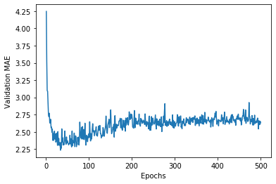

```python
plt.plot(range(1, len(average_mae_history) + 1), average_mae_history)
plt.xlabel('Epochs')
plt.ylabel('Validation MAE')
```

To make the trend easier to see, we:

- omit the first 10 MAE points
- smooth the points with an exponential moving average

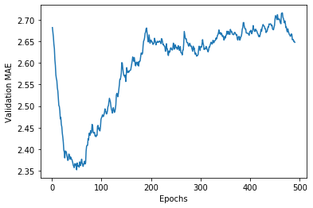

```python
def smooth_curve(points, factor=0.9):
    smoothed_points = []
    for point in points:
        if smoothed_points:
            previous = smoothed_points[-1]
            smoothed_points.append(previous * factor + point * (1 - factor))
        else:
            smoothed_points.append(point)
    return smoothed_points

smooth_mae_history = smooth_curve(average_mae_history[10:])

plt.plot(range(1, len(smooth_mae_history) + 1), smooth_mae_history)
plt.xlabel('Epochs')
plt.ylabel('Validation MAE')
```

The MAE stops improving after 50 epochs. Once we have finalize the parameters, we can train the production model.

```python
model = build_model()
model.fit(train_data, train_targets, epochs=50, batch_size=1, verbose=0)
test_mse_score, test_mae_score = model.evaluate(test_data, test_targets)

print(test_mae_score)
```

```
2.6500394344329834
```

The model is now off by ~$2,600.